# Analysis

## Using Random Forest Model

### Train the Random Forests Model

```r
## RandomForest with 10x cross validation
fitControl <- trainControl(method="cv",
                           number=10,
                           classProbs=T,
                           summaryFunction=twoClassSummary)


set.seed(1234) # for reproducible results

## evaluate on train set based on area under the ROC (AUC)
RF <- train(x=x_train,
             y=y_train,
             method="rf",
             trControl=fitControl,
             tuneGrid=expand.grid(mtry=c(4,5,6,7,8, 10, 15, 18,30,40)),
             metric='ROC')
## summary of performance across each value of tuning parameters
RF
```

```
## Random Forest
##
##  36 samples
## 231 predictors
##   2 classes: 'Infect1', 'Infect2'
##
## No pre-processing
## Resampling: Cross-Validated (10 fold)
## Summary of sample sizes: 33, 33, 31, 32, 32, 33, ...
## Resampling results across tuning parameters:
##
##   mtry  ROC        Sens       Spec
##    4    0.7250000  0.8833333  0.55
##    5    0.7250000  0.8833333  0.55
##    6    0.7458333  0.8333333  0.55
##    7    0.7083333  0.8666667  0.50
##    8    0.7666667  0.8833333  0.40
##   10    0.7666667  0.8333333  0.55
##   15    0.7416667  0.8333333  0.50
##   18    0.7666667  0.8333333  0.50
##   30    0.7916667  0.8000000  0.50
##   40    0.7916667  0.8000000  0.50
##
## ROC was used to select the optimal model using the largest value.
## The final value used for the model was mtry = 30.
```

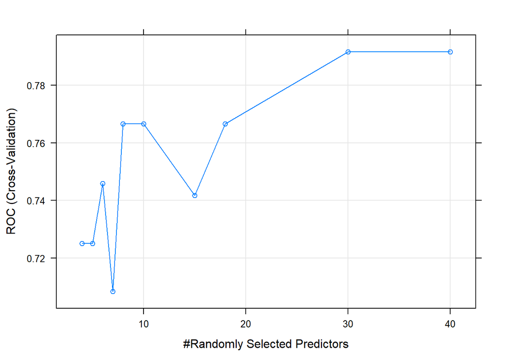

```r
plot(RF, metric = "ROC")
```

```r
RF$bestTune
```

```
##   mtry
## 9   30
```

```r
RF$finalModel
```

```
##
## Call:
##  randomForest(x = x, y = y, mtry = param$mtry)
##                Type of random forest: classification
##                      Number of trees: 500
## No. of variables tried at each split: 30
##
##         OOB estimate of  error rate: 33.33%
## Confusion matrix:
##         Infect1 Infect2 class.error
## Infect1      18       4   0.1818182
## Infect2       8       6   0.5714286
```

### Validation of the Random Forests model

```r
## predicting the validation data:
predRF <- predict(RF,X_test)

## or predicting using the probabilities (nice because you can get ROC)
probsRF <- extractProb(list(model=RF),
                     testX=X_test,
                     testY=y_test)

## removing trainings data
#probsRF <- probsRF[probsRF$dataType!='Training',]

## Make sure the levels are appropriate for twoClassSummary(), ie case group is first level
levs <- c("Infect2", "Infect1")
probsRF$obs <- factor(probsRF$obs, levels = levs)
probsRF$pred <- factor(probsRF$pred, levels = levs)

## Calculating Accuracy
mean(probsRF$obs==probsRF$pred)
```

```
## [1] 0.8833333
```

```r
## see classification prob for each sample in validation set
## pred column shows model predicted label if cutoff for calling label = 0.5
table(probsRF$obs, probsRF$pred)
```

```
##
##           Infect2 Infect1
##   Infect2      25       5
##   Infect1       2      28
```

```r
## summary of performance result on validation set
twoClassSummary(probsRF, lev = levels(probsRF$obs))
```

```
##       ROC      Sens      Spec
## 0.9700000 0.8333333 0.9333333
```

## Summary of models and varaibles importance

### Summary of two models

[output not shown]

### Variables importance using SVM and Random Forests

Based on the importance values of SVM and RF, we think following 14 features are most significant for higher infectious rates.

- median_year_structure_built
- employed_manufacturing
- commute_45_59_mins
- commuters_by_subway_or_elevated
- peoplepersqmile
- area
- owner_occupied_housing_units_lower_value_quartile
- occupation_production_transportation_material
- owner_occupied_housing_units_median_value
- employed_other_services_not_public_admin
- no car
- vacant_housing_units
- commuters_by_bus
- gini index

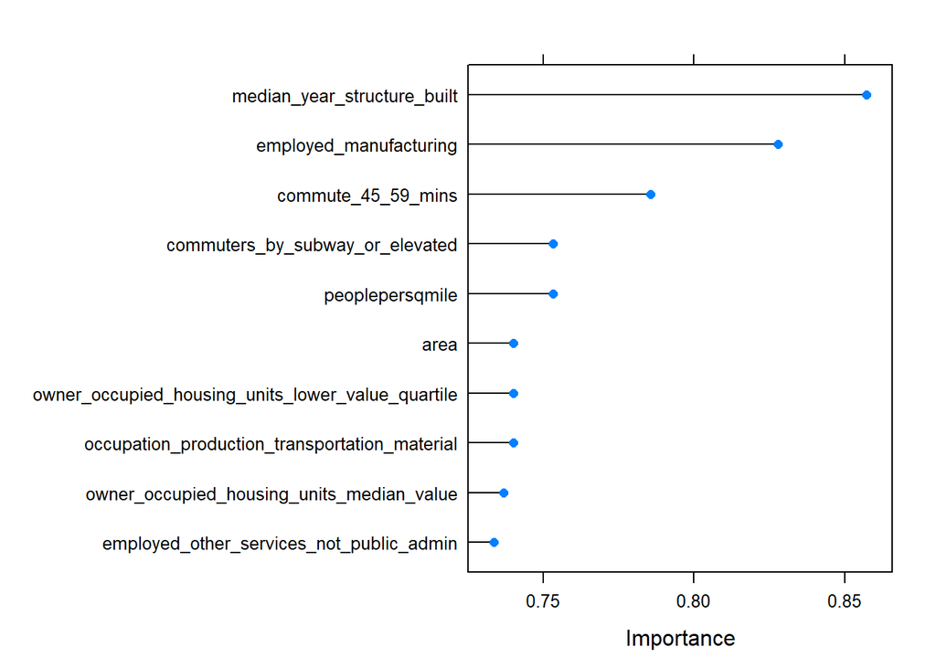

```r
#Variable Importance Top 10 variables in SVM

SVMImp <- varImp(SVM, scale = FALSE)
#head(SVMImp)
#plot(SVMImp, top = 10)
plot(SVMImp, top = 10)
```

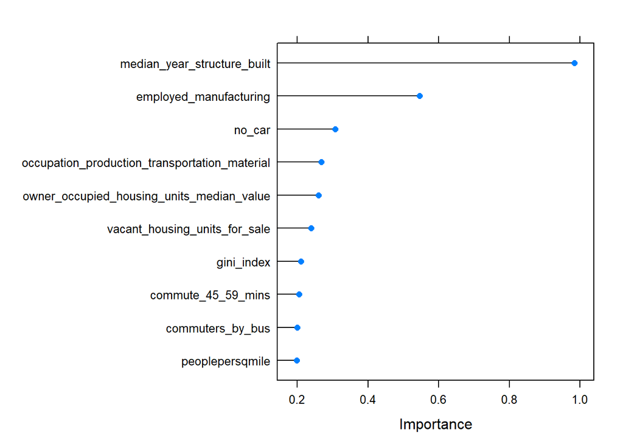

```r
#Variable Importance Top 10 variables in RF
RFImp <- varImp(RF, scale = FALSE)
#head(RFImp)
#plot(RFImp, top = 20)
plot(RFImp, top = 10)
```

```r
#par(mfrow=c(1,2))
#par(mar=c(1, 1, 1, 1))
```

# Fitting Logistic models

## univarible and multivaraiable models using all 14 different selected features from Random forest models and SVM models

```r
DATA$InfectionBinary<-ifelse(DATA$Infection=="Infect2",1,0)

DATa<-as.data.frame(DATA)
# Explanatory or confounding variables
explanatory = c("median_year_structure_built","employed_manufacturing","commute_45_59_mins","commuters_by_subway_or_elevated","peoplepersqmile","area","owner_occupied_housing_units_lower_value_quartile","owner_occupied_housing_units_median_value","occupation_production_transportation_material","employed_other_services_not_public_admin","no_car","vacant_housing_units","commuters_by_bus","gini_index")



# Explanatory variable of interest
explanatory_multi= c("area","gini_index")

#Dependent Variables
dependent = "InfectionBinary" #


finalfit.glm(DATA,dependent,explanatory, explanatory_multi,metrics = TRUE)
```

```
## [[1]]
##                         Dependent: InfectionBinary
##                        median_year_structure_built        [0.0,1990.0]
##                             employed_manufacturing      [127.0,3160.0]
##                                 commute_45_59_mins     [778.0,14863.0]
##                    commuters_by_subway_or_elevated     [312.0,29314.0]
##                                    peoplepersqmile   [4884.2,125797.9]
##                                               area          [0.6,13.7]
##  owner_occupied_housing_units_lower_value_quartile  [18400.0,705000.0]
##          owner_occupied_housing_units_median_value [27600.0,1073700.0]
##      occupation_production_transportation_material      [878.0,8780.0]
##           employed_other_services_not_public_admin      [323.0,5293.0]
##                                             no_car     [326.0,32435.0]
##                               vacant_housing_units      [321.0,6449.0]
##                                   commuters_by_bus      [776.0,9915.0]
##                                         gini_index           [0.4,0.6]
##       unit     value             OR (univariable)        OR (multivariable)
##  Mean (sd) 0.5 (0.5)    1.00 (1.00-1.00, p=0.002)                         -
##  Mean (sd) 0.5 (0.5)    1.00 (1.00-1.01, p=0.001)                         -
##  Mean (sd) 0.5 (0.5)    1.00 (1.00-1.00, p=0.001)                         -
##  Mean (sd) 0.5 (0.5)    1.00 (1.00-1.00, p=0.001)                         -
##  Mean (sd) 0.5 (0.5)    1.00 (1.00-1.00, p=0.016)                         -
##  Mean (sd) 0.5 (0.5)    0.54 (0.29-0.84, p=0.024) 0.41 (0.19-0.72, p=0.010)
##  Mean (sd) 0.5 (0.5)    1.00 (1.00-1.00, p=0.002)                         -
##  Mean (sd) 0.5 (0.5)    1.00 (1.00-1.00, p=0.001)                         -
##  Mean (sd) 0.5 (0.5)    1.00 (1.00-1.00, p=0.024)                         -
##  Mean (sd) 0.5 (0.5)    1.00 (1.00-1.00, p=0.011)                         -
##  Mean (sd) 0.5 (0.5)    1.00 (1.00-1.00, p=0.003)                         -
##  Mean (sd) 0.5 (0.5)    1.00 (1.00-1.00, p=0.091)                         -
##  Mean (sd) 0.5 (0.5)    1.00 (1.00-1.00, p=0.007)                         -
##  Mean (sd) 0.5 (0.5) 0.09 (0.00-2060.55, p=0.637) 0.00 (0.00-0.47, p=0.047)
##
## [[2]]
##
##  Number in dataframe = 60, Number in model = 60, Missing = 0, AIC = 75.1, C-statistic = 0.756, H&L = Chi-sq(8) 3.55 (p=0.896)
```

## GLM models using Backward elemination (step AIC)

- Here we used backward eleminination using all around all 232 factors
- The final model according to the step wise AIC criteria includes following 18 different factors
- (male_pop + median_age + male_under_5 + male_5_to_9 + male_22_to_24 + male_25_to_29 + male_30_to_34 + male_40_to_44 + male_45_to_49 + male_50_to_54 + male_55_to_59 + male_75_to_79 + female_55_to_59 + female_62_to_64 + white_pop + black_pop + asian_pop + hispanic_pop)

## GLM Model Comparisons

+model1:glm model with only significant parameters obtained from RF and SVM seeems the best model

- area and gini_index are significant parameters

```r
#First we normalize data



# glm model with only  significant parameters obtained from RF and SVM
model1<-glm(InfectionBinary~area+gini_index ,data = DATAFF,family = binomial(link = "logit"),control=glm.control(maxit=50))

# Final GLM models using Backward elemination (step AIC)
model2<-glm(InfectionBinary~ male_pop + median_age + male_under_5 + male_5_to_9 +
    male_22_to_24 + male_25_to_29 + male_30_to_34 + male_40_to_44 +
    male_45_to_49 + male_50_to_54 + male_55_to_59 + male_75_to_79 +
    female_55_to_59 + female_62_to_64 + white_pop + black_pop +
    asian_pop + hispanic_pop,data = DATAFF,family = binomial(link = "logit"),control=glm.control(maxit=50))
```

```r
#Here first remove outliars
cooksd <- cooks.distance(model2)
#In this plot, what seems to be a dark thick black line is actually all our data points. In the right-top corner we see also what seems to be 3 outlier, or a bunch of them grouped
outliers <- rownames(DATAFF[cooksd > 4*mean(cooksd, na.rm=T), ])
print(outliers)#only three outliars
```

```
## [1] "1"  "2"  "14"
```

```r
DATAFF<-DATAFF[!(rownames(DATAFF) %in% outliers),]

# Final GLM models using Backward elemination (step AIC)
model2<-glm(InfectionBinary~ male_pop + median_age + male_under_5 + male_5_to_9 +
    male_22_to_24 + male_25_to_29 + male_30_to_34 + male_40_to_44 +
    male_45_to_49 + male_50_to_54 + male_55_to_59 + male_75_to_79 +
    female_55_to_59 + female_62_to_64 + white_pop + black_pop +
    asian_pop+ hispanic_pop ,data = DATAFF,family = binomial(link = "logit"))
export_summs(model1, model2, exp=TRUE, error_format = "[{conf.low}, {conf.high}], p={p.value}")
```

[output not shown]

```r
summ(model1,exp = T,digits = getOption("jtools-digits", default = 3),confint = getOption("summ-confint", TRUE), conf.method = getOption("summ-conf.method", c("Wald")))
```

| Observations | 60 |
| --- | --- |
| Dependent variable | InfectionBinary |
| Type | Generalized linear model |
| Family | binomial |
| Link | logit |

| χ²(2) | 14.044 |
| --- | --- |
| Pseudo-R² (Cragg-Uhler) | 0.278 |
| Pseudo-R² (McFadden) | 0.169 |
| AIC | 75.133 |
| BIC | 81.416 |

|  | exp(Est.) | 2.5% | 97.5% | z val. | p |
| --- | --- | --- | --- | --- | --- |
| (Intercept) | 3218.911 | 3.135 | 3304794.257 | 2.283 | 0.022 |
| area | 0.412 | 0.209 | 0.812 | -2.563 | 0.010 |
| gini_index | 0.000 | 0.000 | 0.834 | -1.988 | 0.047 |

Standard errors: MLE

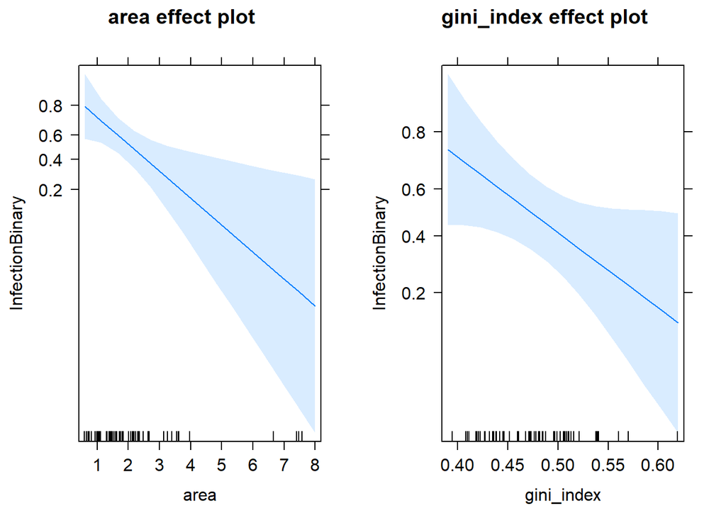

```r
par(mfrow=c(1,1))
par(mar=c(1, 1, 1, 1))
plot(allEffects(model1))
```

# Identify Clusters of Longitudinal Trajectories

Here aim is to dentify zipcodes with significantly different rates of change of postive cases using traj Package.

## Data preprocessing

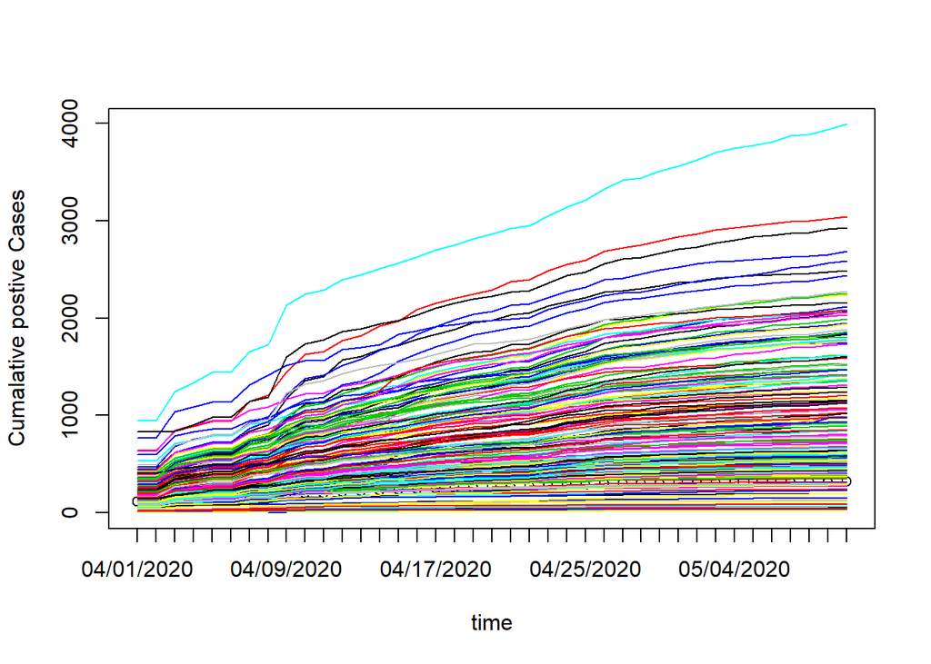

```r
ff<-read.table("time-test-by-zcta_borough.csv",header= T, stringsAsFactors = F, sep=",",fill=T, quote = "")
ff<-na.omit(ff)
#ffLast<-ff[ff$Date=="05/10/2020",]
#head(ffLast)
ff<-data.frame(ff)

ff1<-ff[,c(2,3,5)]


ff1<-data.frame(ff1)

dat<-ff1 %>%
  group_by_at(vars(-Positive)) %>%  # group by everything other than the value column.
  mutate(row_id=1:n()) %>% ungroup() %>%  # build group index
  spread(key=Date, value=Positive) %>%    # spread
  dplyr::select(-row_id)

y.data<-dat[,2:40]

#y.data<-scale(y.data)

#This will plot the trajectories
plot(unlist(y.data[1,]), ylim=c(0,max(y.data, na.rm=T)), ylab="Cumalative postive Cases", xaxt='n', xlab="time" )

for(i in 1:dim(y.data)[1]){ lines(unlist(y.data[i,]), col=i+1)}
axis(1, at=1:39, labels=colnames(y.data))
```

```r
dat<-na.omit(dat)
colnames(dat)<-c("ZipCodes", paste0("X", 1:39, "X"))
dat$ZipCodes<-factor(dat$ZipCodes)
#head(dat)


dattime = matrix(rep(1:39,dim(dat)[1] ), ncol=39, byrow=dim(dat)[1])
dattime<-data.frame(dattime)
dattime$ZipCodes<-dat$ZipCodes
dattime<-dattime[,c("ZipCodes",colnames(dattime)[1:39])]
dat = as.data.frame(dat)
```

## Trajectory analysis

```r
#https://cran.r-project.org/web/packages/traj/vignettes/trajVignette.pdf
s1 = step1measures(dat, dattime, ID = TRUE)
```

```
## [1] "Correlation of m1 and m5 : 1"
## [1] "Correlation of m1 and m6 : 1"
## [1] "Correlation of m1 and m14 : 1"
## [1] "Correlation of m3 and m9 : 1"
## [1] "Correlation of m5 and m6 : 1"
## [1] "Correlation of m5 and m14 : 1"
## [1] "Correlation of m6 and m14 : 1"
## [1] "Correlation of m11 and m15 : 1"
## [1] "Correlation of m12 and m13 : 1"
```

```r
s2 = step2factors(s1)
```

```
## [1] "m5 is removed because it is perfectly correlated with m1"
## [2] "m6 is removed because it is perfectly correlated with m1"
## [3] "m14 is removed because it is perfectly correlated with m1"
## [4] "m9 is removed because it is perfectly correlated with m3"
## [5] "m6 is removed because it is perfectly correlated with m5"
## [6] "m14 is removed because it is perfectly correlated with m5"
## [7] "m14 is removed because it is perfectly correlated with m6"
## [8] "m15 is removed because it is perfectly correlated with m11"
## [9] "m13 is removed because it is perfectly correlated with m12"
## [1] "Computing reduced correlation e-values..."
```

```r
head(s2$factors)
```

| ID | m2 | m4 | m16 |
| --- | --- | --- | --- |
| 10001 | 247 | 25.8 | 0.0931 |
| 10002 | 665 | 31.7 | 0.101 |
| 10003 | 324 | 24 | 0.102 |
| 10004 | 24.1 | 13.9 | 0.125 |
| 10005 | 43.2 | 22 | 0.0926 |
| 10006 | 14.5 | 40.1 | 0.344 |

```r
#Once this step is done, the third step of the procedure consists in clustering the trajectories based on the measures identiﬁed in the factor analysis. Here number of clusters 3

s3 = step3clusters(s2, nclusters = 3)
head(s3$clusters)
```

| ID | cluster |
| --- | --- |
| 10001 | 1 |
| 10002 | 2 |
| 10003 | 1 |
| 10004 | 1 |
| 10005 | 1 |
| 10006 | 1 |

```r
#Cluster Memberships
s3$clust.distr
```

```
##
##  1  2  3
## 91 55 31
```

## Plotting the traj object

- Here we are plotting 10 random trajectories from each cluster and plots them using randomly selected colours.
- Also we can plot,the mean trajectory of every cluster, and the median trajectory of every cluster with 10th and 90th percentiles

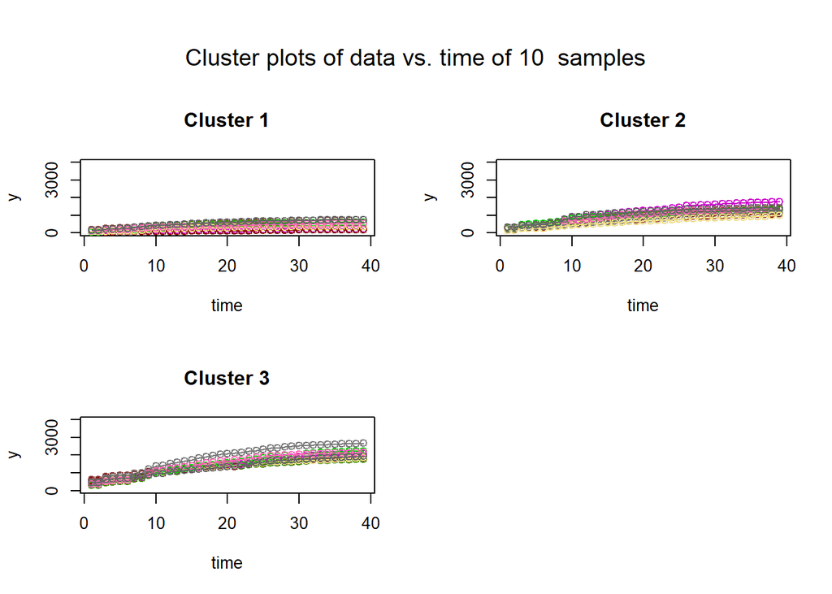

```r
plot(s3)
```

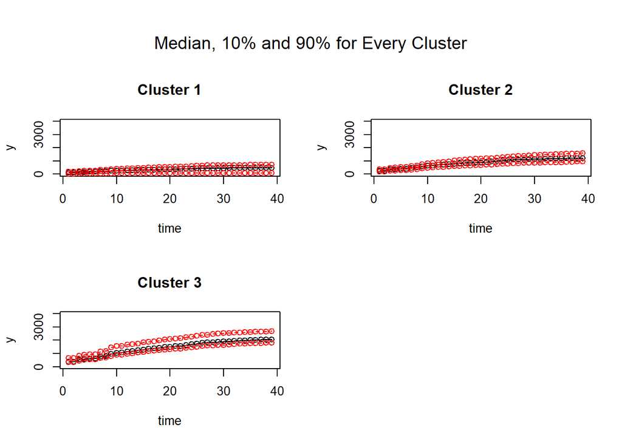

```r
plotMedTraj(s3)
```

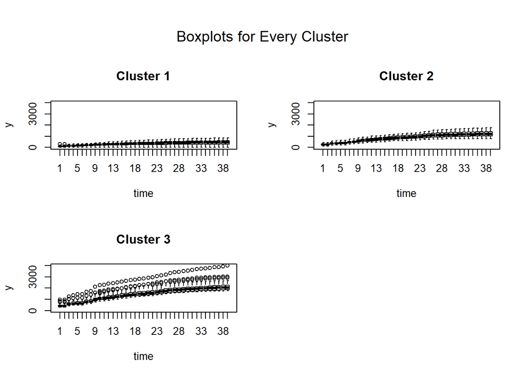

```r
plotBoxplotTraj(s3)
```

```r
#https://towardsdatascience.com/covid-19-infection-in-italy-mathematical-models-and-predictions-7784b4d7dd8d
```

## Now we analze the basic charectristics of each groups

### Comparison of groups using p values

- Here most of the factors are significant in these three groups (most of the cases p <0.001)
- Significant features: Total population, households, gender, gender by older age groups, Race, inclcome level, poverty status, vacant housing units, higher rent, commute, do not having car, commuter by public, less than college, male by education level, employment type, area
- Furture investigation is needed identitify why these covarites related to rate of positive cases.

```r
feature<-read.table("nycjackpotbyzip.csv",header= T, stringsAsFactors = F, sep=",",fill=T, quote = "")
feature$ZipCode<-feature$geo_id
density<-read.table("popbyzipdensity.csv",header= T, stringsAsFactors = F, sep=",",fill=T, quote = "")
DATA11<-merge(feature,density,by="ZipCode",all.x=T)

GR<-s3$clusters
GR$ZipCode<-GR$ID
GROUPFULL<-merge(GR,DATA11, by="ZipCode",all.x=T )

GROUPFULL<-GROUPFULL[,!(colnames(GROUPFULL) %in% c("pop_5_years_over","pop_15_and_over","pop_never_married","pop_now_married","pop_separated","pop_widowed","pop_divorced","speak_only_english_at_home","speak_spanish_at_home","speak_spanish_at_home_low_english","speak_spanish_at_home","speak_spanish_at_home_low_english","aggregate_travel_time_to_work","renter_occupied_housing_units_paying_cash_median_gross_rent","owner_occupied_housing_units_lower_value_quartile","owner_occupied_housing_units_median_value","owner_occupied_housing_units_upper_value_quartile","median_rent","percent_income_spent_on_rent"))]


#missing values frequencies
#freq.na(GROUPFULL)

GROUPFULL<-data.frame(GROUPFULL)


GROUPFULL$cluster<-factor(GROUPFULL$cluster)

pred<-GROUPFULL[, -c(1,2,4,5)]
pred<-pred[,-c(1)]
myVars <- colnames(pred)


#Finding significant factors using chi-square tests for all 230 predictors
tab <- CreateTableOne(vars = myVars, strata = "cluster" , data = GROUPFULL,factorVars="cluster")
tab
```

```
##                                                                             Stratified by cluster
##                                                                              1
##   n                                                                                91
##   total_pop (mean (SD))                                                      29220.54 (15867.86)
##   households (mean (SD))                                                     12502.38 (7971.21)
##   male_pop (mean (SD))                                                       13976.04 (7465.93)
##   female_pop (mean (SD))                                                     15244.49 (8486.89)
##   median_age (mean (SD))                                                        38.49 (4.78)
##   male_under_5 (mean (SD))                                                     863.60 (542.41)
##   male_5_to_9 (mean (SD))                                                      649.90 (392.90)
##   male_10_to_14 (mean (SD))                                                    646.29 (394.51)
##   male_15_to_17 (mean (SD))                                                    369.64 (240.71)
##   male_18_to_19 (mean (SD))                                                    255.07 (312.59)
##   male_20 (mean (SD))                                                          139.99 (119.56)
##   male_21 (mean (SD))                                                          141.26 (115.96)
##   male_22_to_24 (mean (SD))                                                    544.13 (402.92)
##   male_25_to_29 (mean (SD))                                                   1453.19 (1032.36)
##   male_30_to_34 (mean (SD))                                                   1435.70 (1058.11)
##   male_35_to_39 (mean (SD))                                                   1186.74 (771.96)
##   male_40_to_44 (mean (SD))                                                    982.92 (586.45)
##   male_45_to_49 (mean (SD))                                                    976.54 (563.65)
##   male_50_to_54 (mean (SD))                                                    914.23 (474.67)
##   male_55_to_59 (mean (SD))                                                    850.46 (478.57)
##   male_65_to_66 (mean (SD))                                                    265.07 (181.43)
##   male_67_to_69 (mean (SD))                                                    346.75 (218.50)
##   male_70_to_74 (mean (SD))                                                    442.77 (305.74)
##   male_75_to_79 (mean (SD))                                                    314.67 (199.37)
##   male_80_to_84 (mean (SD))                                                    218.11 (175.82)
##   male_85_and_over (mean (SD))                                                 217.48 (188.50)
##   female_under_5 (mean (SD))                                                   810.70 (498.05)
##   female_5_to_9 (mean (SD))                                                    656.77 (424.84)
##   female_10_to_14 (mean (SD))                                                  615.95 (391.69)
##   female_15_to_17 (mean (SD))                                                  362.19 (242.99)
##   female_18_to_19 (mean (SD))                                                  292.07 (463.61)
##   female_20 (mean (SD))                                                        158.09 (143.47)
##   female_21 (mean (SD))                                                        165.10 (149.21)
##   female_22_to_24 (mean (SD))                                                  640.40 (455.49)
##   female_25_to_29 (mean (SD))                                                 1634.91 (1264.97)
##   female_30_to_34 (mean (SD))                                                 1544.71 (1137.77)
##   female_35_to_39 (mean (SD))                                                 1180.91 (748.26)
```

[output cut: 1085 more lines]

```
##   occupation_natural_resources_construction_maintenance (mean (SD))
##   occupation_production_transportation_material (mean (SD))
##   occupation_sales_office (mean (SD))
##   occupation_services (mean (SD))
##   management_business_sci_arts_employed (mean (SD))
##   sales_office_employed (mean (SD))
##   in_grades_1_to_4 (mean (SD))
##   in_grades_5_to_8 (mean (SD))
##   in_grades_9_to_12 (mean (SD))
##   in_school (mean (SD))
##   in_undergrad_college (mean (SD))
##   Row (mean (SD))
##   population (mean (SD))
##   area (mean (SD))
##   peoplepersqmile (mean (SD))
```